# 140.654 Lab 4: CART and Random Forests

Erjia Cui and Elizabeth Colantuoni

## Objective

In the lecture, we discussed Classification and Regression Tree (CART) and Random Forests, and provided an example of constructing the random forest for a continuous variable in R. For today’s lab session, we will focus on the application of random forest to a binary outcome.

## National Medical Expenditure Survey (NMES) Dataset

- Outcome: big expenditure, a binary variable defined as total expenditure > 1000 (bigexp).
- Covariate: major smoking caused disease (mscd), age, gender, marital status, poverty level, education, belt use, ever being a smoker, packs per year of smoking, years since quitting smoked.
- Dataset: the final dataset has 10479 rows and 11 columns.

```r
library(ggplot2)
library(dplyr)

load('./../nmes.rdata')
data <- nmes
data[data=='.'] <- NA
## Prepare the data
data$bigexp <- ifelse(data$totalexp>1000,1,0)
data$mscd <- ifelse(data$lc5+data$chd5 > 0, 1, 0)
data$age <- data$lastage
data$marital <- as.factor(data$marital)
data$educate <- as.factor(data$educate)
data$poverty <- as.factor(data$povstalb)
data$beltuse <- as.factor(data$beltuse)
data$eversmk <- as.numeric(data$eversmk)
data$packyears <- as.numeric(data$packyears)
data$yearsince <- as.numeric(data$yearsince)

dat <- data[,c('bigexp','mscd','male','age','marital','educate',
               'poverty','beltuse','eversmk','packyears','yearsince')]
dat <- dat[complete.cases(dat),]
dim(dat)
```

```
## [1] 10479    11
```

After creating the dataset, we split it into training and testing data.

```r
set.seed(10)
library(caret)
# set aside a random half of the data for testing
train_idx <- sample(nrow(dat), round(nrow(dat)/2), replace=FALSE)
Data_train <- dat[train_idx,]
Data_test <- dat[-train_idx,]
```

## Missing Data Imputation

The missing values can be imputed using the `rfImpute` function from `randomForest` package. However, it gets pretty slow in our example and in general when the sample size is large. Therefore, we only include complete cases in our analysis and leave it as an exercise.

## Logistic Regression

We first fit a logistic regression model using all predictors included in the dataset.

```r
fit_glm <- glm(bigexp~., data = Data_train, family = binomial(link = "logit"))
pred_glm <- predict(fit_glm, newdata = Data_test, type = "response")
table(pred = ifelse(pred_glm>0.5,1,0), truth = Data_test$bigexp) ## set c = 0.5
```

```
##     truth
## pred    0    1
##    0 3116 1452
##    1  217  454
```

## CART and Bagging

A basic classification tree can be built using the `rpart` function of `rpart` package. An alternative is the `tree` function of `tree` package.

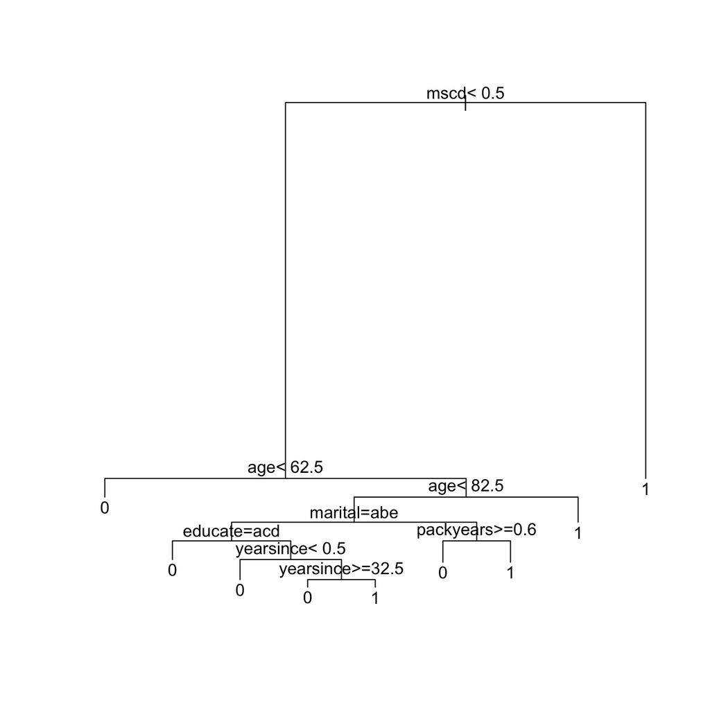

```r
## CART
library(rpart)
tr <- rpart(bigexp~., data = Data_train, method = "class", control=rpart.control(minsplit=10, cp=0.003))
plot(tr); text(tr)
```

```r
pred_tr <- predict(tr, newdata = Data_test, type = "class")
table(pred = pred_tr, truth = Data_test$bigexp)
```

```
##     truth
## pred    0    1
##    0 3033 1399
##    1  300  507
```

Bootstrap aggregation, or bagging, is a general-purpose procedure for reducing the variance of a statistical learning method. Recall that given a set of $n$ independent observations $Z_1,…,Z_n$, each with variance $\sigma^2$, the variance of the mean $\bar{Z}$ of the observations is given by $\sigma^2/n$. In other words, averaging a set of observations reduces variance. Of course, this is not practical because we generally do not have access to multiple training sets.

Instead, we can bootstrap, by taking repeated samples from the (single) training dataset. In this approach we generate $B$ different bootstrapped training data sets. We then train our method on the $b$th bootstrapped training set in order to get $\hat{f}^{*b}(x)$, the prediction at a point $x$. We then average all the predictions to obtain $\hat{f}_{bag}(x)=\frac{1}{B}\sum\limits_{b=1}^B\hat{f}^{*b}(x)$.

```r
# we tune the model with the training data
fit_bag <- train(as.factor(bigexp) ~ ., data=Data_train, method="treebag")

## get predicted values of the testing data
pred_bag <- predict(fit_bag, Data_test)
table(pred = pred_bag, truth = Data_test$bigexp)
```

```
##     truth
## pred    0    1
##    0 2532 1199
##    1  801  707
```

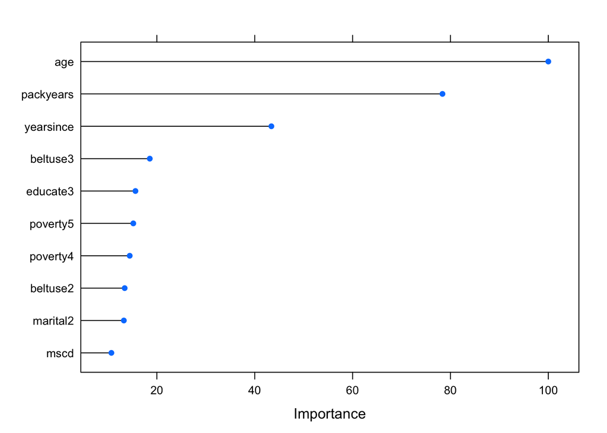

```r
## plot variable importance
plot(varImp(fit_bag), top = 10)
```

## Random Forest

We next try a random forest. Random forests provide an improvement over bagged trees by way of a small tweak that decorrelates the trees. This reduces the variance when we average the trees. As in bagging, we build a number of decision trees on bootstrapped training samples. But when building these decision trees, a random selection of m predictors is chosen as split candidates from the full set of p predictors. The split is allowed to use only one of those m predictors.

### Select m and Number of Trees

We use the `tuneRF` function to select m with the smallest out-of-bag error. After selecting m, we build a random forest object to see if the number of trees is large enough.

```r
library(randomForest)
## fix ntree = 500, select m
tune_rf <- tuneRF(x = Data_train[,2:11], y = as.factor(Data_train[,1]), ntreeTry = 500)
```

```
## mtry = 3  OOB error = 31.66%
## Searching left ...
## mtry = 2     OOB error = 30.84%
## 0.02591923 0.05
## Searching right ...
## mtry = 6     OOB error = 34.71%
## -0.09644364 0.05
```

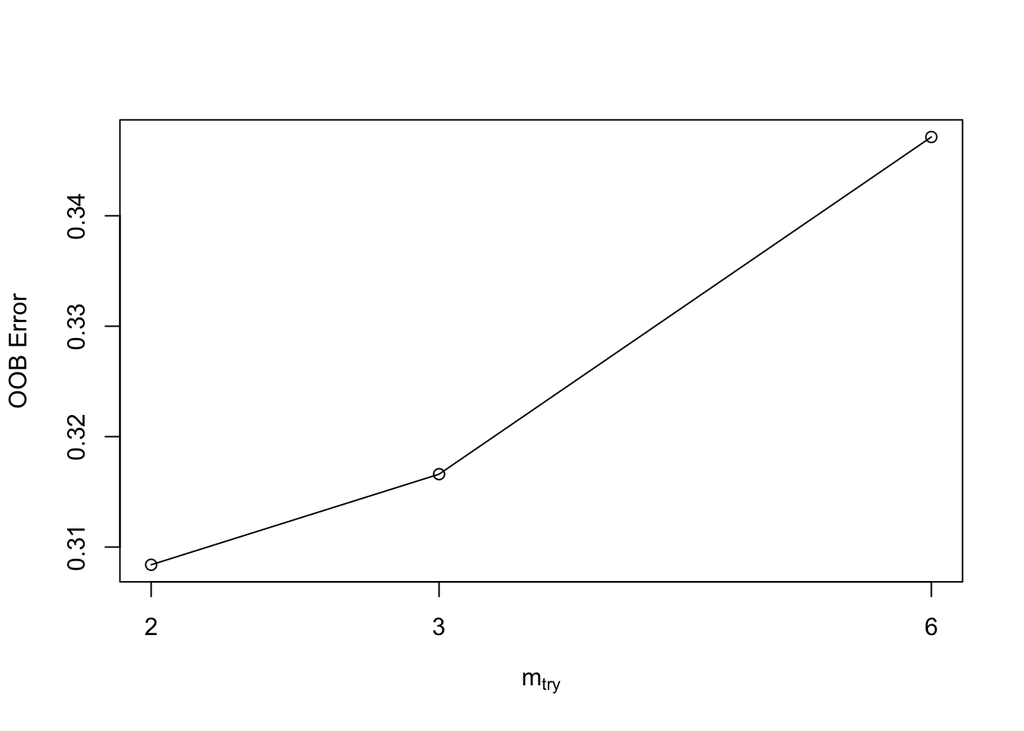

```r
tune_rf
```

```
##       mtry  OOBError
## 2.OOB    2 0.3083969
## 3.OOB    3 0.3166031
## 6.OOB    6 0.3471374
```

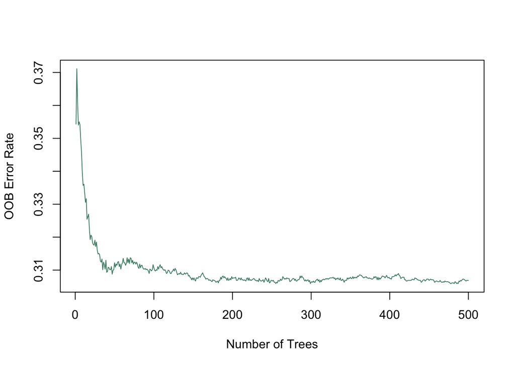

```r
## fix m, plot error vs. ntree to check if 500 is suitable
m <- tune_rf[which.min(tune_rf[,2]),1]
rf_m <- randomForest(x = Data_train[,2:11], y = as.factor(Data_train[,1]), xtest = Data_test[,2:11], ytest = as.factor(Data_test[,1]), mtry = m, ntree = 500)
plot(1:500, rf_m$err.rate[,1], col = "aquamarine4", type = "l", xlab = "Number of Trees",
     ylab = "OOB Error Rate")
```

From the plot, 500 trees are large enough. A smaller number of trees, say 300, can also achieve similar accuracy.

### Prediction and Variable Importance

After selecting m and ntree, we build the random forest model and obtain votes as well as predicted values. The votes are the out-of-bag votes for each observation in the training set, and prediction is the 0/1 assignment which is the most frequently occurring out-of-bag outcome in each terminal node. In our example for each subject, each of the 500 classification trees in the random forest casts a vote of whether it has big medical expenditure. This is a major difference between the random forest models of binary and continuous outcomes.

```r
## get out-of-bag predictions from the model
pred_OOB <- rf_m$predicted

## get out-of-bag votes from the model
pred_vote <- as.data.frame(rf_m$votes)
pred_vote$pred_class <- pred_OOB
head(pred_vote)
```

```
##              0          1 pred_class
## 673  0.9356436 0.06435644          0
## 4897 0.9125683 0.08743169          0
## 7307 0.7921348 0.20786517          0
## 2144 0.9471154 0.05288462          0
## 1953 0.3715596 0.62844037          1
## 9946 0.8742857 0.12571429          0
```

To obtain the predicted values for future observations or validation sample, you can use either predict command or specify those samples in the `xtest` and `ytest` arguments when building a random forest. Since we specify the testing dataset when building the model, the results are stored in the `test` element of fitted object.

```r
## get the predicted values of testing data
pred_test <- rf_m$test$predicted
table(pred = pred_test, truth = Data_test$bigexp)
```

```
##     truth
## pred    0    1
##    0 3137 1486
##    1  196  420
```

The variable importance plot is obtained using the `varImpPlot` function of `randomForest` package.

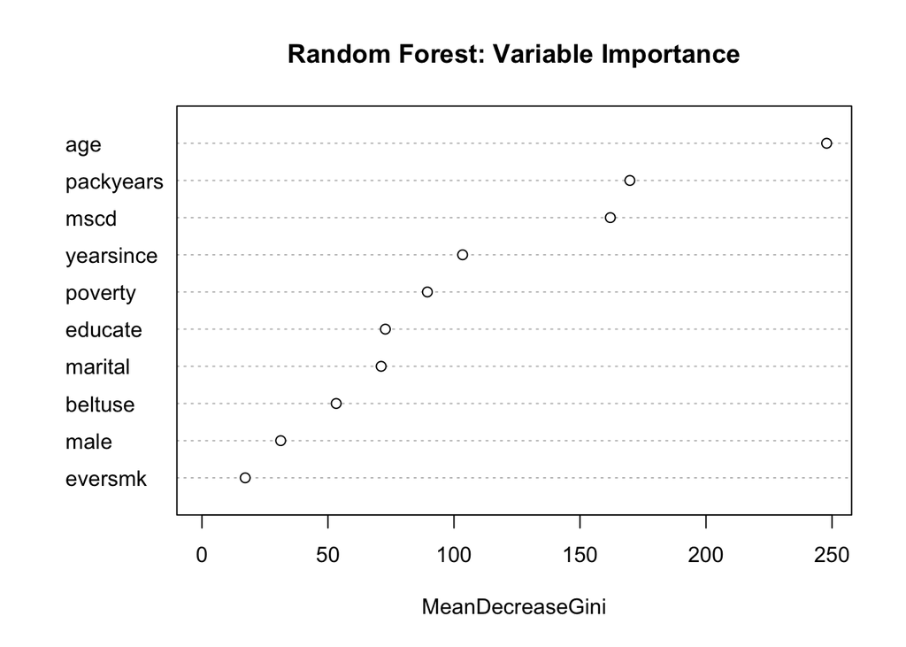

```r
## variable importance plot
varImpPlot(rf_m, main = "Random Forest: Variable Importance")
```

```r
## variable importance table
var.imp <- data.frame(importance(rf_m, type=2))
var.imp$Variables <- row.names(var.imp)
var.imp[order(var.imp$MeanDecreaseGini, decreasing = T), ]
```

```
##           MeanDecreaseGini Variables
## age              247.85688       age
## packyears        169.78354 packyears
## mscd             162.03635      mscd
## yearsince        103.42907 yearsince
## poverty           89.44644   poverty
## educate           72.77990   educate
## marital           71.10950   marital
## beltuse           53.26729   beltuse
## male              31.25515      male
## eversmk           17.17431   eversmk
```

### Create a Summary Average Tree

After obtaining out-of-bag predictions from random forest, we could create a summary of the random forest using these predictions as the outcome and create a CART.

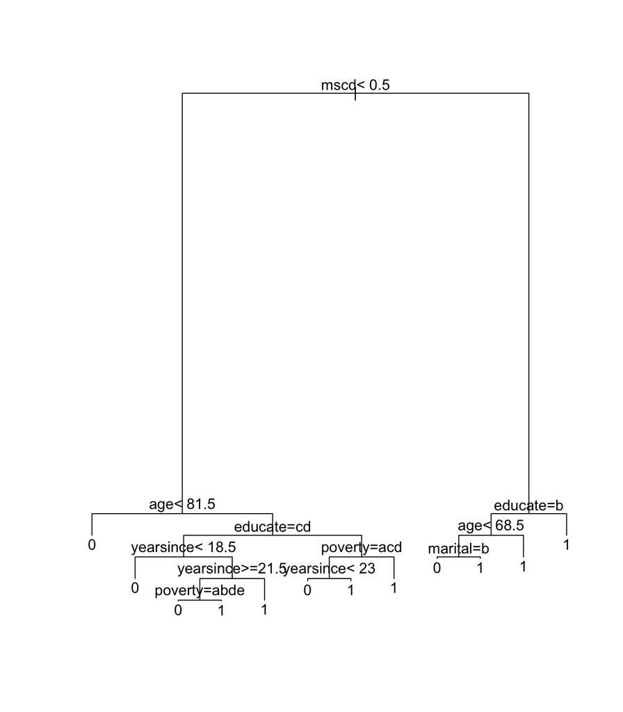

```r
Data_train$pred_OOB <- pred_OOB
tr_summary <- rpart(pred_OOB~., data = Data_train[,-1], method = "class", control=rpart.control(minsplit=10, cp=0.001))
plot(tr_summary); text(tr_summary)
```